title: “COVID-19 analysis report” author: “Ostap Romanchak, Madiyar Seidaly, Wing Lun Lim, Emily Chiu” date: “2023-12-19” output: pdf_document

## Introduction

The COVID-19 pandemic has affected many different people globally in many different ways. In this report we wish to investigate if age and gender have an effect on mortality, based on model data related to COVID-19, as well as to examine the severity of different symptoms.

## Figures

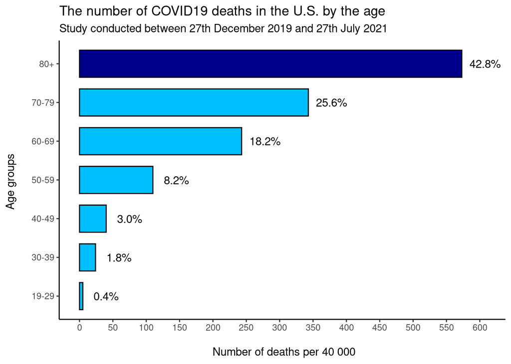

**Figure 1.** As the age increases the mortality rate rises, with the most significant deaths seen in the 80+ category. The assumed reason for the observations can be due to deteriorating immunity with the age.

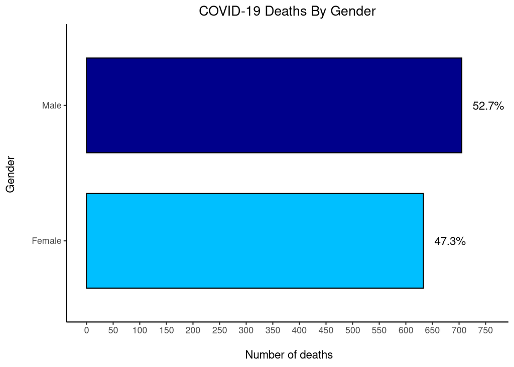

**Figure 2.** COVID-19 has a male bias in mortality despite less males were sampled. The confirmed cases included 43279 females and 38376 males, and in the 1338 deaths, 633 were females and 705 were males. This bias might be caused by the higher rate of high-risk behaviors and comorbidities in males (Singh *et al*., 2020). An association of low testosterone levels in males with increased COVID-19 mortality is suggested, but further research is needed (Giagulli *et al*., 2021; Yassin *et al*., 2022).

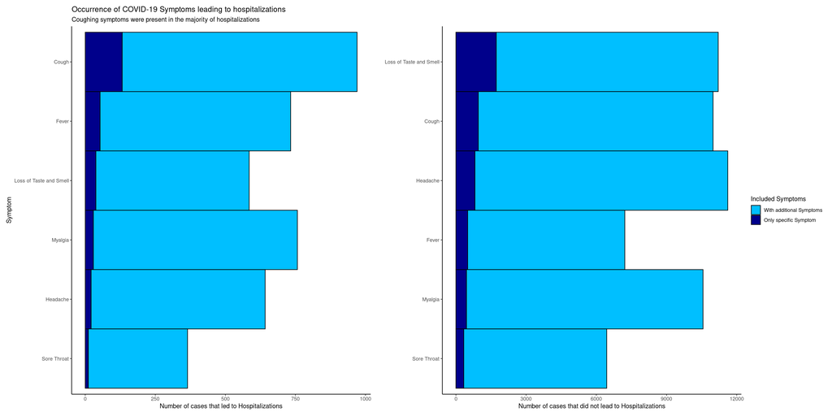

**Figure 3.** The different symptoms associated with COVID-19 vary in prevalence among cases where individuals were and were not hospitalized. Sore throat was the least prevalent in both groups. Coughing was the most prevalent among those hospitalized both as an individual symptom and as a collective of symptoms, while the loss of taste and smell was the individual most prevalent symptom among those who weren’t hospitalized, with headaches being most prevalent collectively along with other symptoms.

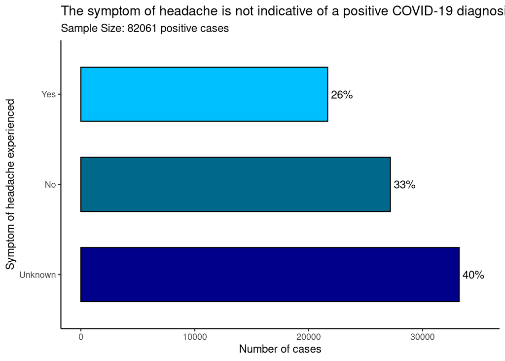

**Figure 4.** The symptom of headache itself does not indicate a positive COVID-19 diagnosis. Only 26% of the people with COVID-19 reported with a headache. 33% of them did not experience a headache, and the status for the remaining cases could not be confirmed, thus suggesting there is no positive correlation.

## Conclusion

Human demographics have been shown to influence the mortality of the various COVID-19 symptoms, with different symptoms such as headaches being more common among people. Consideration of different demographics and awareness of symptoms will be important in future global responses to worldwide diseases.

## Reference List:

Giagulli, V.A., Guastamacchia, E., Magrone, T., Jirillo, E., Lisco, G., De Pergola, G. and Triggiani, V., 2021. ‘Worse progression of COVID‐19 in men: is testosterone a key factor?’, *Andrology*, 9(1), pp. 53-64.

Singh, S., Chowdhry, M., Chatterjee, A. and Khan, A., 2020. ‘Gender-based disparities in COVID-19 patient outcomes: A propensity-matched analysis’, *MedRxiv*.

Yassin, A., Sabsigh, R., Al‐Zoubi, R.M., Aboumarzouk, O.M., Alwani, M., Nettleship, J. and Kelly, D., 2022. ‘Testosterone and Covid‐19: an update’, *Reviews in Medical Virology*, 33(1).